# Business Statistics Mid-Term Assessment IB94X0 2024-2025 #1

5663451

This is to certify that the work I am submitting is my own. All external references and sources are clearly acknowledged and identified within the contents. I am aware of the University of Warwick regulation concerning plagiarism and collusion.

No substantial part(s) of the work submitted here has also been submitted by me in other assessments for accredited courses of study, and I acknowledge that if this has been done an appropriate reduction in the mark I might otherwise have received will be made.

AI was used in the preparation of this work. It was used in the development of the code: It was used to provide example uses of functions or approaches to elements of the challenges which were then interpreted by me and modified to be applicable to this data/report.

# Section 1

```r
knitr::opts_chunk$set(echo = TRUE)
library(tidyverse)
library(lubridate)
library(gridExtra)
library(kableExtra)
```

## Introduction to Analysis

This script performs a statistical analysis of daily footfall data for various locations in York, aiming to help a promoter determine the optimal location for setting up a stall to reach the maximum number of passers-by.

The analysis includes: 1. Data integrity checks to ensure the dataset is suitable for analysis. 2. Summary statistics (e.g., mean, standard deviation) of daily footfall for each location. 3. Visualizations of footfall distributions per location. 4. Comparative statistical tests (t-tests) to evaluate footfall differences between key locations (Coney Street and Stonegate) both for overall and weekend-only data.

The code is structured to be reproducible, with clear comments and a consistent approach to packages, allowing future analysts to adapt it to new datasets or expand upon this analysis.

## Data Dictionary

This data comes from cameras that automatically measure the number of people who walk past a particular location: the “footfall”. The variables can be described in the following way:

```r
data_dictionary <- data.frame(
  Column_Name = c("Date", "SiteName", "LocationName", "WeekDay", "TotalCount", "Recording_ID"),
  Data_Type = c("Date", "Text", "Text", "Text", "Numeric", "Numeric"),
  Description = c(
    "The date of footfall measurement in YYYY-MM-DD format.",
    "The name of the city where footfall is recorded (all entries are 'York').",
    "Specific location within York where footfall was measured.",
    "Day of the week corresponding to each date of footfall measurement.",
    "Total number of people counted by cameras at the location on the given date.",
    "Unique identifier for each recording."
  )
)

# Print data dictionary
print(data_dictionary)
```

```
##    Column_Name Data_Type
## 1         Date      Date
## 2     SiteName      Text
## 3 LocationName      Text
## 4      WeekDay      Text
## 5   TotalCount   Numeric
## 6 Recording_ID   Numeric
##                                                                    Description
## 1                       The date of footfall measurement in YYYY-MM-DD format.
## 2    The name of the city where footfall is recorded (all entries are 'York').
## 3                   Specific location within York where footfall was measured.
## 4          Day of the week corresponding to each date of footfall measurement.
## 5 Total number of people counted by cameras at the location on the given date.
## 6                                        Unique identifier for each recording.
```

## Read Data

```r
# Load the footfall data
footfall_data <- read_csv("~/Downloads/York_Footfall_data.csv")
# Preview the data
head(footfall_data)
```

```
## # A tibble: 6 × 6
##   Date       SiteName LocationName             WeekDay  TotalCount Recording_ID
##   <date>     <chr>    <chr>                    <chr>         <dbl>        <dbl>
## 1 2015-01-01 York     Church Street            Thursday       1952       375836
## 2 2015-01-01 York     Coney Street             Thursday      12220       724862
## 3 2015-01-01 York     Micklegate               Thursday       5559       451020
## 4 2015-01-01 York     Parliament Street at M&S Thursday       7802       523989
## 5 2015-01-01 York     Stonegate                Thursday      14004       382272
## 6 2015-01-02 York     Church Street            Friday         3451       464381
```

## Data Integrity Checks

```r
# Inspect the data
summary(footfall_data)
```

```
##       Date              SiteName         LocationName         WeekDay
##  Min.   :2015-01-01   Length:8204        Length:8204        Length:8204
##  1st Qu.:2016-02-15   Class :character   Class :character   Class :character
##  Median :2017-03-31   Mode  :character   Mode  :character   Mode  :character
##  Mean   :2017-05-11
##  3rd Qu.:2018-08-06
##  Max.   :2019-12-31
##
##    TotalCount      Recording_ID
##  Min.   :   402   Min.   :    25
##  1st Qu.:  7454   1st Qu.:253536
##  Median : 16990   Median :501402
##  Mean   : 16854   Mean   :500099
##  3rd Qu.: 22808   3rd Qu.:746919
##  Max.   :328310   Max.   :999828
##  NA's   :10       NA's   :100
```

```r
# There are 10 missing values in TotalCount and 100 missing values in Recording_ID. Since we will mostly be working with TotalCount, we can ignore the missing Recording_ID values. For the missing values in TotalCount, we can remove them in the data cleaning.

# Check data types
str(footfall_data)
```

```
## spc_tbl_ [8,204 × 6] (S3: spec_tbl_df/tbl_df/tbl/data.frame)
##  $ Date        : Date[1:8204], format: "2015-01-01" "2015-01-01" ...
##  $ SiteName    : chr [1:8204] "York" "York" "York" "York" ...
##  $ LocationName: chr [1:8204] "Church Street" "Coney Street" "Micklegate" "Parliament Street at M&S" ...
##  $ WeekDay     : chr [1:8204] "Thursday" "Thursday" "Thursday" "Thursday" ...
##  $ TotalCount  : num [1:8204] 1952 12220 5559 7802 14004 ...
##  $ Recording_ID: num [1:8204] 375836 724862 451020 523989 382272 ...
##  - attr(*, "spec")=
##   .. cols(
##   ..   Date = col_date(format = ""),
##   ..   SiteName = col_character(),
##   ..   LocationName = col_character(),
##   ..   WeekDay = col_character(),
##   ..   TotalCount = col_double(),
##   ..   Recording_ID = col_double()
##   .. )
##  - attr(*, "problems")=<externalptr>
```

```r
# Necessary columns have appropriate data types (Date as Date, TotalCount as numeric).

# Check for spelling inconsistencies or unexpected values in categorical columns.

# Unique values in LocationName and WeekDay
unique_locations <- unique(footfall_data$LocationName)
print(unique_locations)
```

```
## [1] "Church Street"            "Coney Street"
## [3] "Micklegate"               "Parliament Street at M&S"
## [5] "Stonegate"                "Parliament Street"
```

```r
unique_weekdays <- unique(footfall_data$WeekDay)
print(unique_weekdays)
```

```
## [1] "Thursday"  "Friday"    "Saturday"  "Sunday"    "Monday"    "Tuesday"
## [7] "Wednesday"
```

```r
# We can see that there are 2 Locations named Parliament Street and Parliament Street at M&S. Let us check if they are the same or different streets by checking for duplicates.

# Duplicate Records Check
duplicate_rows <- footfall_data[duplicated(footfall_data), ]
print(duplicate_rows)
```

```
## # A tibble: 0 × 6
## # ℹ 6 variables: Date <date>, SiteName <chr>, LocationName <chr>,
## #   WeekDay <chr>, TotalCount <dbl>, Recording_ID <dbl>
```

```r
# There are no duplicates. Therefore we can conclude the streets are different individual streets and keep them as they are.

# Outlier Detection in TotalCount
# Identify any extreme values in TotalCount which may indicate data entry or measurement errors.

# Summary of TotalCount to identify unusual values
summary(footfall_data$TotalCount)
```

```
##    Min. 1st Qu.  Median    Mean 3rd Qu.    Max.    NA's
##     402    7454   16990   16854   22808  328310      10
```

```r
# TotalCount ranges from 402 to 328,310 with a median of 16,990 and a mean of 16,854. This suggests potential outliers (e.g., 328,310), as the upper quartile is only 22,808. Outliers may represent special events or errors, so further investigation is needed.

# Distribution Analysis of TotalCount
# Evaluate the distribution of TotalCount to identify potential anomalies or biases in recording
# Plot the distribution of TotalCount
p.footfall.distribution <- ggplot(footfall_data, aes(x = TotalCount)) +
  geom_histogram(bins = 150, fill = "darkred", alpha = 0.9) +
  labs(title = "Distribution of Daily Footfall Counts", x = "Total Count", y = "Frequency") +
  theme_minimal() +
  coord_cartesian(xlim = c(0, 50000))

# It appears the daily footfall counts are right-skewed. While lower footfall counts are typical, there are occasional days with exceptionally high footfall.
```

## Data Cleaning

Focus on two crucial steps in data preprocessing: 1. Removal of Missing Values: We will remove missing data points to ensure our dataset is complete and ready for analysis. 2. Removal of Outliers: We will remove outliers that were identified in the data integrity check. These steps are essential to enhance the quality of our dataset and improve the accuracy of our results.

```r
# Remove missing values in TotalCount
footfall_data_clean <- footfall_data %>%
   drop_na(TotalCount)

# Verify the changes
summary(footfall_data_clean)
```

```
##       Date              SiteName         LocationName         WeekDay
##  Min.   :2015-01-01   Length:8194        Length:8194        Length:8194
##  1st Qu.:2016-02-16   Class :character   Class :character   Class :character
##  Median :2017-04-01   Mode  :character   Mode  :character   Mode  :character
##  Mean   :2017-05-12
##  3rd Qu.:2018-08-06
##  Max.   :2019-12-31
##
##    TotalCount      Recording_ID
##  Min.   :   402   Min.   :    25
##  1st Qu.:  7454   1st Qu.:253669
##  Median : 16990   Median :501662
##  Mean   : 16854   Mean   :500246
##  3rd Qu.: 22808   3rd Qu.:747263
##  Max.   :328310   Max.   :999828
##                   NA's   :100
```

```r
# We can see that there are now no missing values in TotalCount

# Boxplot to visualize outliers in TotalCount by location
p.footfall.outliers <- ggplot(footfall_data_clean, aes(x = "", y = TotalCount)) +
  geom_boxplot(outlier.color = "blue", fill = "pink") +
  facet_wrap(~ LocationName, scales = "free_y") +
  labs(title = "Boxplots of Total Footfall by Location", x = "", y = "Total Count") +
  theme_minimal() +
  theme(
    strip.text = element_text(size = 10, face = "bold"),
    axis.text.x = element_blank(),
    axis.ticks.x = element_blank()
  )

# We can confirm the presence of outliers in all the locations, with some like Stonegate having significantly more variation than others. For this instance, we will use arbitrary thresholds after examining the summary statistics to remove outliers.

# Calculate summary statistics for each location
summary_stats <- footfall_data_clean %>%
  group_by(LocationName) %>%
  summarise(min_count = min(TotalCount, na.rm = TRUE),
            max_count = max(TotalCount, na.rm = TRUE),
            median_count = median(TotalCount, na.rm = TRUE),
            mean_count = mean(TotalCount, na.rm = TRUE),
            sd_count = sd(TotalCount, na.rm = TRUE))
print(summary_stats)
```

```
## # A tibble: 6 × 6
##   LocationName             min_count max_count median_count mean_count sd_count
##   <chr>                        <dbl>     <dbl>        <dbl>      <dbl>    <dbl>
## 1 Church Street                  402     26848        4267       4352.    1389.
## 2 Coney Street                  2960     51050       22046.     23507.    6608.
## 3 Micklegate                    1309     98180        6930.      7487.    4800.
## 4 Parliament Street             1227     53749       21888.     22631.    6610.
## 5 Parliament Street at M&S      7802     53057       20798      22432.    7750.
## 6 Stonegate                     1297    328310       17530.     19902.   17826.
```

```r
# Define minimum and maximum thresholds
min_threshold <- 1000
max_threshold <- 35000

# Filter out data points outside the thresholds
footfall_data_clean <- footfall_data_clean %>%
  filter(TotalCount >= min_threshold & TotalCount <= max_threshold)

# Display the filtered data
head(footfall_data_clean)
```

```
## # A tibble: 6 × 6
##   Date       SiteName LocationName             WeekDay  TotalCount Recording_ID
##   <date>     <chr>    <chr>                    <chr>         <dbl>        <dbl>
## 1 2015-01-01 York     Church Street            Thursday       1952       375836
## 2 2015-01-01 York     Coney Street             Thursday      12220       724862
## 3 2015-01-01 York     Micklegate               Thursday       5559       451020
## 4 2015-01-01 York     Parliament Street at M&S Thursday       7802       523989
## 5 2015-01-01 York     Stonegate                Thursday      14004       382272
## 6 2015-01-02 York     Church Street            Friday         3451       464381
```

```r
# This filters out rows where TotalCount is below 1000 or above 35000. These thresholds are based on excluding values that are likely due to unusual conditions or anomalies rather than typical daily foot traffic patterns.
```

## Summary Table

```r
# Summary statistics for each location
summary_stats <- footfall_data_clean %>%
  group_by(LocationName) %>%
  summarise(
    StartDate = min(Date, na.rm = TRUE),
    EndDate = max(Date, na.rm = TRUE),
    MeanFootfall = mean(TotalCount, na.rm = TRUE),
    StdDevFootfall = sd(TotalCount, na.rm = TRUE),
    MaxFootfall = max(TotalCount, na.rm = TRUE),
    MinFootfall = min(TotalCount, na.rm = TRUE)
  )

# Display summary statistics as a table
kable(summary_stats, format = "html", caption = "Summary Statistics of Footfall by Location") %>%
  kable_styling(full_width = FALSE)
```

Summary Statistics of Footfall by Location

| LocationName | StartDate | EndDate | MeanFootfall | StdDevFootfall | MaxFootfall | MinFootfall |
| --- | --- | --- | --- | --- | --- | --- |
| Church Street | 2015-01-01 | 2017-06-18 | 4361.160 | 1378.255 | 26848 | 1271 |
| Coney Street | 2015-01-01 | 2019-12-31 | 22213.552 | 4976.696 | 34901 | 2960 |
| Micklegate | 2015-01-01 | 2019-12-31 | 7215.389 | 1806.757 | 21082 | 1309 |
| Parliament Street | 2015-06-08 | 2019-12-31 | 21783.396 | 5436.751 | 34791 | 1227 |
| Parliament Street at M&S | 2015-01-01 | 2015-06-07 | 21024.701 | 5835.929 | 34922 | 7802 |
| Stonegate | 2015-01-01 | 2019-12-31 | 18378.702 | 5914.666 | 34927 | 1297 |

## Visualisation

As only 2019 data is to be used for further analysis, filtering out and then producing plots to show distribution of footfall across all days in the dataset.

```r
# Filter data to only include the year 2019
footfall_data_clean_2019 <- filter(footfall_data_clean, year(Date) == 2019)

# Scatter plot of footfall over time, separated by location
p.footfall_over_time <- ggplot(footfall_data_clean_2019, aes(x = Date, y = TotalCount, color = LocationName)) +
   geom_point(alpha = 0.6) +
   facet_wrap(~ LocationName, scales = "free_y") +
   labs(title = "Footfall Over Time by Location (2019)", x = "Date", y = "Daily Footfall") +
   theme_minimal() +
   theme(legend.position = "none")
```

## Conduct t-Tests

```r
# Daily Comparison Between Locations
# Filter data for Coney Street and Stonegate in 2019
coney_vs_stonegate <- footfall_data_clean_2019 %>%
    filter(LocationName %in% c("Coney Street", "Stonegate"))

# Perform t-test
t_test_daily <- t.test(TotalCount ~ LocationName, data = coney_vs_stonegate)
print(t_test_daily)
```

```
##
##  Welch Two Sample t-test
##
## data:  TotalCount by LocationName
## t = 4.4852, df = 687.61, p-value = 8.536e-06
## alternative hypothesis: true difference in means between group Coney Street and group Stonegate is not equal to 0
## 95 percent confidence interval:
##  1043.643 2668.780
## sample estimates:
## mean in group Coney Street    mean in group Stonegate
##                   20330.26                   18474.05
```

```r
# t-test shows that Coney Street had a higher mean footfall count (M = 20,330.26) compared to Stonegate (M = 18,474.05), with a mean difference of approximately 1,856 people. This difference was statistically significant (t(687.61)=4.49, p<0.001).

# Weekend Comparison
# Filter for weekends only
weekend_footfall <- coney_vs_stonegate %>%
    filter(WeekDay %in% c("Saturday", "Sunday"))

# Perform t-test
t_test_weekend <- t.test(TotalCount ~ LocationName, data = weekend_footfall)
print(t_test_weekend)
```

```
##
##  Welch Two Sample t-test
##
## data:  TotalCount by LocationName
## t = 0.33124, df = 185.99, p-value = 0.7408
## alternative hypothesis: true difference in means between group Coney Street and group Stonegate is not equal to 0
## 95 percent confidence interval:
##  -1472.436  2066.666
## sample estimates:
## mean in group Coney Street    mean in group Stonegate
##                   24697.17                   24400.05
```

```r
# t-test shows that Coney Street had a mean weekend footfall count of 24,697.17, while Stonegate had a mean of 24,400.05, with a mean difference of approximately 297 people. This difference was not statistically significant, (t(185.99)=0.33, p=0.741).
```

# Section 2

This report presents the findings from a statistical analysis conducted on daily footfall data across several locations in York, aimed at guiding the promoter’s choice for optimal stall placement based on foot traffic volume.

Data was sourced from footfall monitoring cameras at designated locations, recording passerby counts for analysis. To maintain data integrity, initial processing filtered out around 300 potential outliers and addressed missing values. This preparation ensured consistency and reliability in the results.

The analysis includes a statistical summary of average daily footfall, covering mean, standard deviation, and observed range, shown in Table 1. These metrics provide an initial snapshot of the variability in foot traffic across different locations.

Table 1. Summary of Daily Footfall by Location

| LocationName | StartDate | EndDate | MeanFootfall | StdDevFootfall | MaxFootfall | MinFootfall |
| --- | --- | --- | --- | --- | --- | --- |
| Church Street | 2015-01-01 | 2017-06-18 | 4361.160 | 1378.255 | 26848 | 1271 |
| Coney Street | 2015-01-01 | 2019-12-31 | 22213.552 | 4976.696 | 34901 | 2960 |
| Micklegate | 2015-01-01 | 2019-12-31 | 7215.389 | 1806.757 | 21082 | 1309 |
| Parliament Street | 2015-06-08 | 2019-12-31 | 21783.396 | 5436.751 | 34791 | 1227 |
| Parliament Street at M&S | 2015-01-01 | 2015-06-07 | 21024.701 | 5835.929 | 34922 | 7802 |
| Stonegate | 2015-01-01 | 2019-12-31 | 18378.702 | 5914.666 | 34927 | 1297 |

To explore foot traffic patterns more closely, visual representations of footfall distribution were created. These visualizations reveal a right-skewed distribution, with some locations, such as Stonegate, showing higher variance(Figure 1).

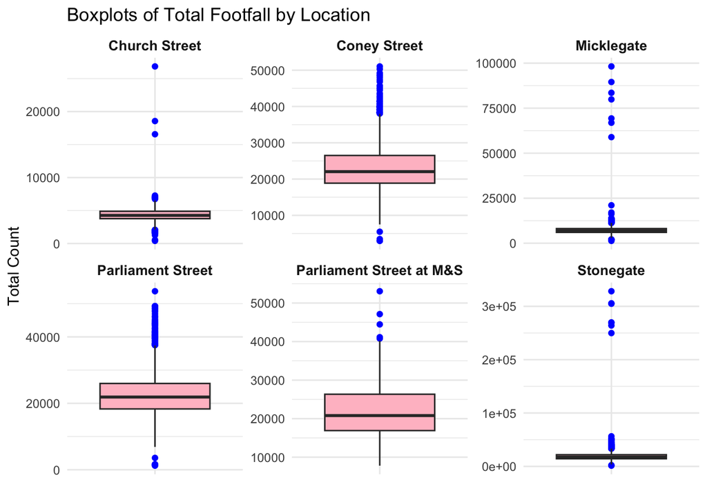

The distribution of footfall is shown in figure 2.

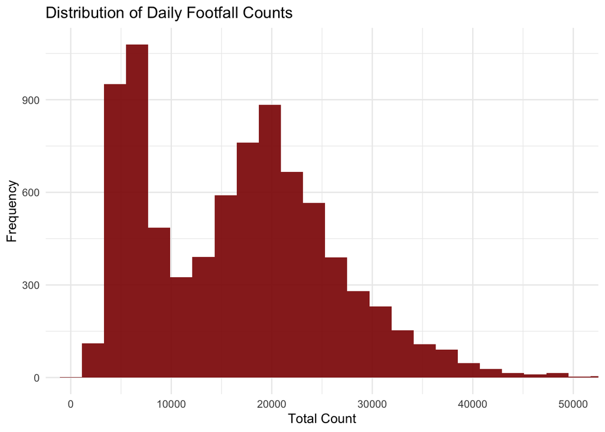

A scatter plot analysis further illustrates consistent high traffic at Coney Street, with fewer fluctuations compared to Stonegate. This suggests a steady potential customer stream throughout the week (Figure 3)

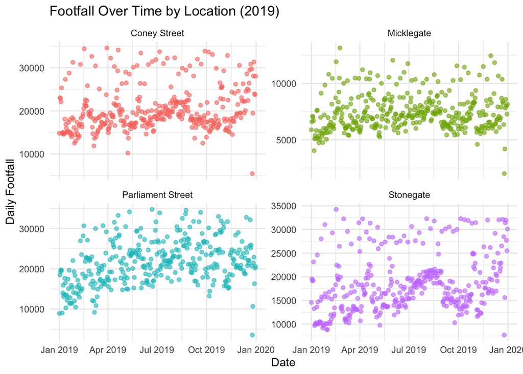

The t-test analysis shows that the mean daily footfall count at Coney Street (20,330.26) is significantly higher than that at Stonegate (18,474.05). This difference is statistically significant, t(687.61) = 4.49, p < 0.001, with a 95% confidence interval for the mean difference ranging from 1043.64 to 2668.78.

During weekends, the mean footfall at Coney Street was 24,697.17, slightly higher than at Stonegate, which averaged 24,400.05. However, this difference of approximately 297 people is not statistically significant, t(185.99) = 0.33, p = 0.741, indicating that weekend footfall counts are similar between the two locations.

In conclusion, for daily operations, Coney Street is the preferred location due to its higher and more stable footfall. On weekends, either Coney Street or Stonegate would be effective, as both attract similar traffic.